# Korpus einfaches Deutsch (KED)

Eine digitale Ressource für den datengestützten Fremdsprachenunterricht auf Anfängerniveau

Daniel Jach

Southwest Jiaotong University

Gunther Dietz

Universität Bamberg

27. August 2024

## Prolog: Was ist ein *Korpus*?

**Korpus** „Endliche Menge von konkreten sprachlichen Äußerungen, die als empirische Grundlage für sprachwiss. Untersuchungen dienen“ (Bußmann 2008, 378).

- Texte oder Gespräche
- digital oder auf Papier
- qualitativ oder quantitativ

| Korpus | n Wörter |
| --- | --- |
| Deutsches Referenzkorpus | 57,6 Mrd. |
| DWDS-Kernkorpus 21 | 15,5 Mio. |
| GeWiss Deutsch | 742.374 |
| … | … |

**Korpora im Einsatz**

- Korpora in traditionellen Teilgebieten der Linguistik
- Korpora als Trainingsmaterial für maschinelle Verfahren (NLP)
- Korpora in der Sprachlernforschung und **Sprachvermittlung** (Mukherjee 2002)
- …

## Problemaufriss

**Wo bleibt die „Korpusrevolution“ im DaFZ-Unterricht?** (Krekeler 2021, 191)

∅ Korpora auf geeignetem Sprachniveau

∅ Konkrete Unterrichtsszenarien

[figure not shown]

Jach und Dietz (2024)

✓ Korpus von Texten in einfachem Deutsch

✓ Konkretes Unterrichtsszenario: Trennbare Partikelverben

## KED: Profil

Das KED besteht aus **bildungssprachlichen Sachtexten** in **einfachem Deutsch**.

**Einfaches Deutsch** sind Texte, die sich an Lesende mit (vermutlich) eingeschränkter Lesekompetenz richten (Bredel und Maaß 2016, 537).

| KED | n |
| --- | --- |
| Quellen | 14 |
| Texte | 6.841 |
| Absätze | 71.908 |
| Sätze | 224.042 |
| Wörter | 2.803.454 |

[figure not shown]

[figure not shown]

[figure not shown]

[figure not shown]

[figure not shown]

[figure not shown]

## KED: Profil

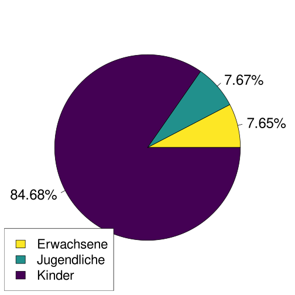

Adressatengruppe

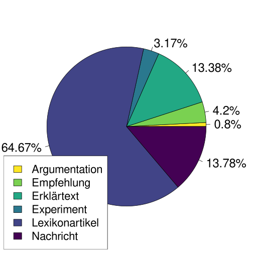

Textsorte

## KED: Profil

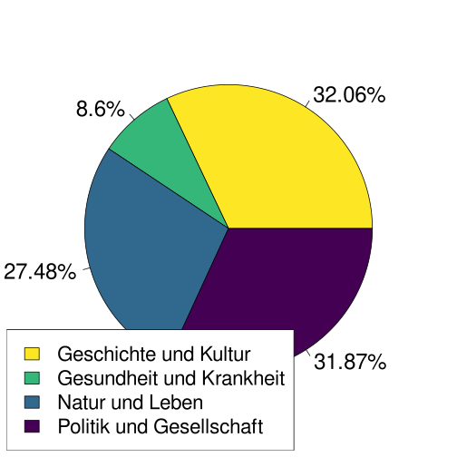

Thema

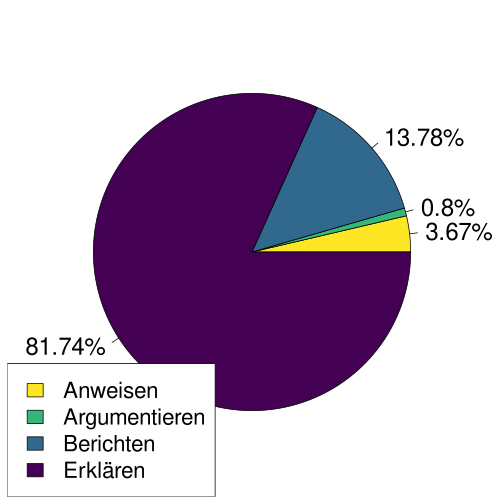

Vertextungsstrategie

## Unterrichtsszenario

**DDL (‚datengestütztes Lernen‘)** (Johns 1991; Gilquin und Granger 2022)

Lernende bearbeiten Belege zielsprachlicher Strukturen aus Korpora.

**Beispiel: Trennbare Partikelverben**

(1)

Er **lächelte** mich jetzt auch tatsächlich nicht mehr ganz so gnadenstoßerbittend aus seinem Gramgesicht **an**.

Walser, Martin: *Halbzeit*, Frankfurt a. M.: Suhrkamp 1997 [1960], S. 284 (DWDS)

(2)

1. In meinem Heimatland **sieht** die Situation ein bisschen anders **aus**.
2. Ich **stimme** dieser Aussage nicht **zu**.
3. Es **fällt** sofort **auf**, dass auf der einen Seite der Anteil […]

Deutsch im Studium Lernerkorpus (DISKO)

Lernende von Deutsch als Fremdsprache vermeiden **Partikelverben**, besonders dann, wenn **Verbbasis und Partikel getrennt** auftreten (Jach und Zeng, o. J.).

## Unterrichtsszenario

| **Thema** | ??? |
| --- | --- |
| **Textsorte** | ??? |
| **Sprachhandlung** | ??? |
| **Fertigkeiten** | ??? |
| **Struktur** | Trennbare Partikelverben |
| **Niveau** | A2 |
| **Material** | • Lese- und Hörtext • Beispiele im Kontext (KWICs) |

## Unterrichtsszenario

[figure not shown]

https://ked-portal.shinyapps.io/korpussuche/

## Unterrichtsszenario

| **Thema** | Ernährung, Kocharten |
| --- | --- |
| **Textsorte** | Empfehlung, Anleitung |
| **Sprachhandlung** | anweisen |
| **Fertigkeiten** | Lesen, Hören, Schreiben |
| **Struktur** | Trennbare Partikelverben |
| **Niveau** | A2 |
| **Material** | • Lese- und Hörtext • Beispiele im Kontext (KWICs) |

**Lese- und Hörtext**

[video not shown]

**KWICs**

1. Die Lebensmittel **brennen** darin nicht so schnell **an** . Die Beschichtung darf aber nicht zerkratzen . Benutzen
2. **geben** Sie ein bis zwei Teelöffel Fett **hinein** . Braten Sie das Lebensmittel kurz an . Geben
3. **Schalten** Sie den Herd auf niedrige Hitze **zurück** . Nur beim Nudelkochen ist das anders . Da
4. Wie wird’s gemacht ? **Stellen** Sie den Ofen **an** . Legen Sie das Lebensmittel auf ein Blech
5. In diesem Artikel stellen wir einige Arten vor , wie man Lebensmittel garen kann . Was passiert
6. kochen . Und dann legen Sie die Nudeln hinein . Für welche Lebensmittel eignet sich Kochen ? Suppe
7. vor dem Kochen . Schalten Sie den Herd ab . Jetzt geben Sie das Lebensmittel dazu - das
8. Wie wird’s gemacht ? Heizen Sie den Grill vor . Legen Sie das Lebensmittel auf einen Rost
9. Herd ab . Jetzt geben Sie das Lebensmittel dazu - das Wasser darf nicht mehr kochen . Legen
10. stehen . Das Lebensmittel saugt die gesamte Flüssigkeit auf . Für welche Lebensmittel eignet sich Quellen ? Reis
11. schalten Sie den Herd auf niedrige Hitze zurück . Nehmen Sie den Deckel nicht vom Topf
12. in einen Topf und geben Sie Wasser dazu . Das Essen muss vollständig unter Wasser stehen
13. ein Lebensmittel sich . Gegarte Lebensmittel sehen anders aus als rohe Lebensmittel und sie schmecken anders
14. Fett hinein . Braten Sie das Lebensmittel kurz an . Geben Sie ein bisschen Wasser dazu . Legen
15. schalten Sie den Herd auf mittlere Hitze zurück . Nehmen Sie den Deckel nicht vom Topf

## Unterrichtsszenario

**Einstieg**  
→ **Rezipieren & verstehen**  
→ **Fokussieren**  
→ **Analysieren und abstrahieren**  
→ **Produzieren** (Amorocho und Pfeiffer 2023)

**Einstieg**

Die Lernenden sprechen über traditionelle Speisen in ihrem Heimatland oder ihr Lieblingsessen und die eigenen Kochkompetenzen.

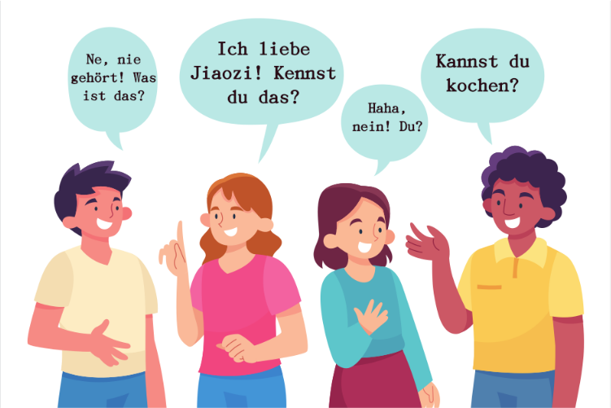

**Rezipieren: Hören und Lesen**

Die Lernenden hören den Text an und ordnen dabei verschiedenen Kocharten den richtigen Bildern zu.

Anschließend lesen sie den Text und kontrollieren/korrigieren ihre Kochart-Bild-Zuordnungen.

(weitere Verständnisaufgaben)

[video not shown]

**Reproduzieren**

Die Lernenden wiederholen die Zielstrukturen aus dem Text, indem sie z.B. Anweisungen in der richtigen Reihenfolge angeben.

[interactive chart not shown]

**Fokussieren**

Die Lernenden fokussieren die Zielstruktur, indem Sie z.B. die Bestandteile der Verben in den KWICs markieren.

**Aufgabe** *Finden Sie alle mehrteiligen Verben in folgenden Auszügen aus dem Text. Markieren Sie alle Verbteile. Notieren Sie Ihre Ergebnisse. Wie viele Teile hat jedes Verb?*

…  
b. **geben** Sie ein bis zwei Teelöffel Fett **hinein** . Braten Sie das Lebensmittel kurz an . Geben  
c. **Schalten** Sie den Herd auf niedrige Hitze **zurück** . Nur beim Nudelkochen ist das anders . Da  
d. Wie wird’s gemacht ? Stellen Sie den Ofen an . Legen Sie das Lebensmittel auf ein Blech  
f. kochen . Und dann legen Sie die Nudeln hinein . Für welche Lebensmittel eignet sich Kochen ? Suppe  
g. vor dem Kochen . Schalten Sie den Herd ab . Jetzt geben Sie das Lebensmittel dazu - das  
…

*geben … hinein*  
*schalten … zurück*  
…

**Analysieren und abstrahieren**

Die Lernenden analysieren getrennte Partikelverben im Kontext und markieren oder notieren repetitive Bestandteile der Auszüge.

Die Lernenden erarbeiten anhand ihrer Analyse der Korpusbelege ein grobes Verbbasis-Partikel-Schema.

**Aufgabe** *Vergleichen Sie die Auszüge. Markieren Sie dabei Ausdrücke und Elemente, die sich wiederholen. Welches Muster erkennen Sie? Notieren Sie.*

_____ ___ _____ ___

…  
b. **geben** Sie ein bis zwei Teelöffel Fett **hinein** . Braten Sie das Lebensmittel kurz an . Geben  
c. **Schalten** Sie den Herd auf niedrige Hitze zurück . Nur beim Nudelkochen ist das anders . Da  
d. Wie wird’s gemacht ? Stellen Sie den Ofen an . Legen Sie das Lebensmittel auf ein Blech  
f. kochen . Und dann legen Sie die Nudeln hinein . Für welche Lebensmittel eignet sich Kochen ? Suppe  
g. vor dem Kochen . Schalten Sie den Herd ab . Jetzt geben Sie das Lebensmittel dazu - das  
…

**Aufgabe** *Verben beschreiben Handlungen. Welche Informationen geben die verschiedenen Verbteile? Welche anderen Teile kommen noch vor?*

**Aufgabe** *Diskutieren Sie: Was will der Schreiber beim Leser mit diesen Formulierungen erreichen?*

**Wortschatz erweitern, Zielstruktur einüben**

Die Lernenden erhalten Verben und Auszüge aus einem weiteren Text zum Thema (Blick ins KED: Text BZE/00025 *Zubereitung, Teil 2*). Sie erhalten die Verben in Infinitivform und recherchieren ihre Bedeutung. Sie integrieren die Verben in getrennter Form anschließend in den richtigen Kontext.

Das erweitert den Wortschatz und übt die Zielstruktur ein.

Zur Vorbereitung auf die nachfolgende Schreibaufgabe formulieren die Lernenden freie Sätze mit den vorgegebenen Verben.

**Aufgabe** *Recherchieren Sie die Bedeutung der folgenden Verben im Wörterbuch. Schreiben Sie die Verben dann in der passenden Form in den richtigen Textauszug.*

auflegen - anbraten - **abfüllen** - abkühlen - mitverwenden - …

1. Tagen verzehrt , lagern Sie ihn im Kühlschrank . Am besten **füllen** Sie die Speisen in Portionsgröße **ab**
2. lösen sich diese zum Teil in der Garflüssigkeit . Deshalb _____ Sie die Garflüssigkeit nach Möglichkeit ___
3. einem flachen Topf . Geben Sie Gemüse , Fisch oder Geflügelstücke dazu und _____ Sie es kurz ___
4. Gießen Sie wenig Wasser dazu und _____ den Deckel ___
5. warmhalten . Möchten Sie fertig gegartes Gemüse erst zu einem späteren Zeitpunkt essen , _____ Sie es ___
6. …

**Aufgabe** *Formulieren Sie einige eigene Sätze zum Thema in der erarbeiteten Form. Verwenden Sie die vorgegebenen Verben oder andere trennbare Verben.*

**Produzieren: Schreiben und/oder Sprechen**

Die Lernenden schreiben in Gruppen oder in Partnerarbeit Kochanleitungen und verwenden dabei die Zielstrukturen.

Sie instruieren anschließend andere Lernende bei der Zubereitung (Gruppenpuzzle) oder verteilen die Anleitungen zum Nachkochen zu Hause (Hausaufgabe).

**Aufgabe** *Formulieren Sie eine Kochanleitung für eine traditionelle Speise aus Ihrem Heimatland oder für Ihre Lieblingsspeise.*

Wir kochen Jiaozi!  
Kaufen Sie zuerst folgende Zutaten ein: …  
Schneiden Sie den Chinakohl klein.  
…  
Bringen Sie Wasser zum Kochen.  
Legen Sie die Jiaozi vorsichtig hinein.  
…

## Fazit

[figure not shown]

Jach und Dietz (2024)

- KED aus Texten in einfachem Deutsch für datengestütztes DaFZ-Unterricht auf niedrigen Niveaustufen
- KED-Portal für didaktisch orientierte Korpussuche und Weiterverarbeitung für DaFZ-Lehrende
- Unterrichtszenario *Getrennte Partikelverben im Kontext von Kochanweisungen*

Porträt KED

[figure not shown]

https://doi.org/10.48694/kordaf.3996

Portal KED

[figure not shown]

https://ked-portal.shinyapps.io/korpussuche/

## Vielen Dank für Ihre Aufmerksamkeit

## Literatur

Daniel Jach und Gunther Dietz, *Korpus einfaches Deutsch*, Asiatische Germanistenkonferenz, Qingdao, 25. bis 28. August 2024

Amorocho, Simone, und Christian Pfeiffer. 2023. „Konstruktionsdidaktik - Grundzüge einer sprachdidaktischen Konzeption“. *Deutsch als Fremdsprache* 60 (3): 131–47.

Bredel, Ursula, und Christiane Maaß. 2016. *Leichte Sprache: theoretische Grundlagen, Orientierung für die Praxis*. Sprache im Blick. Berlin: Dudenverlag.

Bußmann, Hadumod. 2008. *Lexikon der Sprachwissenschaft*. 4, durchgesehene und bibliographisch ergänzte. Stuttgart: Alfred Kröner Verlag.

Gilquin, Gaëtanelle, und Sylviane Granger. 2022. „Using Data-Driven Learning in Language Teaching“. In *The Routledge Handbook of Corpus Linguistics*, herausgegeben von Anne O’Keeffe und Michael J. McCarthy, 2. Aufl., 430–42. Routledge. https://doi.org/10.4324/9780367076399-30.

Jach, Daniel, und Gunther Dietz. 2024. „Korpus einfaches Deutsch“. *Korpora Deutsch als Fremdsprache* 4 (1): 123–30. https://doi.org/https://doi.org/10.48694/kordaf.3996.

Jach, Daniel, und Jing Zeng. o. J. „Analyzing the Use of Particle Verbs in German as a Foreign Language: Unproductive Particle Separation and Data-Driven Learning Interventions“. *Eingereicht*.

Johns, Tim. 1991. „Should you be persuaded: Two samples of data-driven learning materials“. *Empirical Language Research* 4: 1–16.

Krekeler, Christian. 2021. „Korpustraining und datengestütztes Lernen im Wirtschaftsdeutsch-Unterricht“. *Zeitschrift für Interkulturellen Fremdsprachenunterricht* 26 (1): 161–95. http://tujournals.ulb.tu-darmstadt.de/index.php/zif/.

Mukherjee, Joybrato. 2002. *Korpuslinguistik und Englischunterricht: Eine Einführung*. Frankfurt am Main: Peter Lang.